# MLB Starting Pitcher Clustering

Tyler Fuelling

August 16, 2020

The goal of this project was to analyze starting pitchers in the MLB at first by their pitching style rather than their level of success. Then, to examine different compositions of MLB starting pitching rotations based on the different pitching styles of the pitchers that make them up, and to see which rotation compostions have lead to the most success. The examination of different starting pitching styles will be accomplished through k-means clustering.

We begin by loading the data into a dataframe. The dataset contains data for all MLB starting picthers who have pitched at least 100 total innings during the 2010 through 2019 seasons. Because the k-means clustering will be done based on pitching style rather than the pitcher's level of success, the dataset contains metrics such as fastball percentage, pitch velocities, standardized runs by pitch type, expected velocity, first-strike percentage, strikeout percentage, walk percentage, and swinging strike percentage, rather than conventional pitching success metrics, such as ERA or WHIP. Data obtained from https://www.fangraphs.com/.

```r
# read the data file into a dataframe
df <- read.csv("sp_data 2010-2019.csv", header = TRUE, check.names = TRUE)
head(df)
```

```
##           ï..Name    Team     IP    K.   BB. BABIP   GB.   LD.   FB. IFFB.   EV
## 1 Clayton Kershaw Dodgers 1995.0 0.280 0.056 0.267 0.469 0.199 0.332 0.119 86.9
## 2  Jose Fernandez Marlins  471.1 0.312 0.074 0.292 0.430 0.245 0.325 0.077 88.9
## 3    Jacob deGrom    Mets 1101.2 0.286 0.061 0.291 0.452 0.217 0.330 0.110 86.9
## 4     Mike Soroka  Braves  200.1 0.200 0.059 0.289 0.502 0.247 0.251 0.123 88.3
## 5  Walker Buehler Dodgers  318.2 0.288 0.058 0.270 0.458 0.207 0.335 0.067 88.6
## 6       Rich Hill   - - -  465.1 0.293 0.077 0.265 0.418 0.188 0.394 0.136 87.2
##   Soft.  Med. Hard. FB..1   SL.   CT.   CB.   CH.   SF. KN. wFB.C wSL.C wCT.C
## 1 0.214 0.507 0.279 0.564 0.290    NA 0.130 0.017    NA  NA  1.07  1.88    NA
## 2 0.178 0.518 0.305 0.551 0.213    NA 0.126 0.110    NA  NA  0.57  3.46    NA
## 3 0.209 0.497 0.295 0.561 0.220    NA 0.083 0.136    NA  NA  0.94  1.55    NA
## 4 0.183 0.464 0.353 0.641 0.240    NA    NA 0.119    NA  NA  1.00  1.14    NA
## 5 0.180 0.432 0.388 0.600 0.138 0.116 0.128 0.018    NA  NA  1.40  1.80  1.16
## 6 0.210 0.451 0.339 0.534 0.050 0.013 0.391 0.012 0.001  NA  1.13 -0.27  1.42
##   wCB.C wCH.C wSF.C wKN.C O.Swing. Swing. Contact. Zone. F.Strike. SwStr.  LOB.
```

[output cut: 20 more lines]

```r
# renaming the columns of the the df for easier use
colnames(df)[1] <- "name"
df <- df %>% rename(team = Team, ip = IP, k_percent = K., bb_percent = BB., babip = BABIP, gb_percent = GB.,
                    ld_percent = LD., fb_percent = FB.,iffb_percent = IFFB., ev = EV, soft_percent = Soft.,
                    med_percent = Med., hard_percent = Hard., fa_percent = FB..1, sl_percent = SL.,
                    ct_percent = CT., cb_percent = CB., ch_percent = CH., sf_percent = SF., kn_percent = KN.,
                    fa_standardized_runs = wFB.C, sl_standardized_runs = wSL.C, ct_standardized_runs = wCT.C,
                    cb_standardized_runs = wCB.C, ch_standardized_runs = wCH.C, sf_standardized_runs = wSF.C,
                    kn_standardized_runs = wKN.C, fa_velo = FBv, sl_velo = SLv, ct_velo = CTv, cb_velo = CBv,
                    ch_velo = CHv, sf_velo = SFv, kn_velo = KNv, o_swing_percent = O.Swing.,
                    z_swing_percent = Z.Swing., swing_percent = Swing., o_contact_percent = O.Contact.,
                    z_contact_percent = Z.Contact., contact_percent = Contact., zone_percent = Zone.,
                    first_strike_percent = F.Strike., swinging_strike_percent = SwStr., lob_percent = LOB.,
                    pace = Pace, player_id = playerid)
```

Because starting pitchers do not all throw the same types of pitches, there are many NA values present in the dataset where data is missing. For example, a pitcher who does not throw a slider will have NA values for slider percentage and slider velocity.

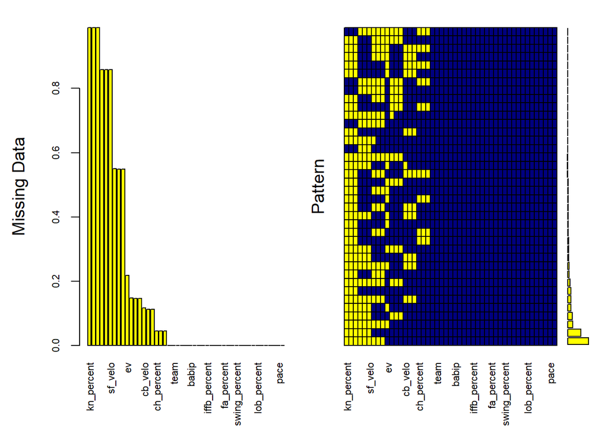

```
##
##  Variables sorted by number of missings:
##                 Variable     Count
##               kn_percent 0.9894515
##     kn_standardized_runs 0.9894515
##                  kn_velo 0.9894515
##               sf_percent 0.8586498
##     sf_standardized_runs 0.8586498
##                  sf_velo 0.8586498
##                  ct_velo 0.5506329
##               ct_percent 0.5485232
##     ct_standardized_runs 0.5485232
##                       ev 0.2172996
##                  sl_velo 0.1476793
##               sl_percent 0.1455696
##     sl_standardized_runs 0.1455696
##                  cb_velo 0.1160338
##               cb_percent 0.1118143
##     cb_standardized_runs 0.1118143
##               ch_percent 0.0443038
##     ch_standardized_runs 0.0443038
##                  ch_velo 0.0443038
##                     name 0.0000000
##                     team 0.0000000
##                       ip 0.0000000
##                k_percent 0.0000000
##               bb_percent 0.0000000
##                    babip 0.0000000
##               gb_percent 0.0000000
##               ld_percent 0.0000000
##               fb_percent 0.0000000
##             iffb_percent 0.0000000
##             soft_percent 0.0000000
##              med_percent 0.0000000
##             hard_percent 0.0000000
##               fa_percent 0.0000000
##     fa_standardized_runs 0.0000000
##          o_swing_percent 0.0000000
##            swing_percent 0.0000000
##          contact_percent 0.0000000
##             zone_percent 0.0000000
##     first_strike_percent 0.0000000
##  swinging_strike_percent 0.0000000
##              lob_percent 0.0000000
##                  fa_velo 0.0000000
##          z_swing_percent 0.0000000
##        o_contact_percent 0.0000000
##        z_contact_percent 0.0000000
##                     pace 0.0000000
##                player_id 0.0000000
```

```r
# examining the NA values present in the dataframe
aggr(df, col=c('navyblue', 'yellow'), numbers = TRUE, sortVars = TRUE, labels = names(df), cex.axis = .7,
     gap = 3, ylab = c("Missing Data", "Pattern"))
```

Because there are so many missing elements in the dataset, all of these NA values must be addressed in some fashion. So, multivariate imputation will be utiilized to address this issue. Imputation is a method used to fill in the missing values of a dataset with values that are estimated using the rest of the values in the dataset. In this project, a specific type of imputation, multivariate imputation via chained equations, will be implemented using the MICE package in R. This process is further explained here: https://medium.com/coinmonks/dealing-with-missing-data-using-r-3ae428da2d17.

```r
# removing the player id column - we don't need it
df <- subset(df, select = -c(player_id))
# creating a new subset of the dataframe without the name and team columns to be used for multivariate imputation (MICE package)
mice_subset <- subset(df, select = -c(name, team))

# Multivariate Imputation via Chained Equations
# creating 15 imputed data sets because the original data set contained about 15% NA's, max iterations of 50, using "predictive mean matching"
imputed_data <- mice(mice_subset, m = 15, maxit = 50, method = 'pmm', seed = 123)
# merging the 15 imputed data sets and appending the imputed data to the mice_subset dataframe
mice_subset <- merge_imputations(mice_subset, imputed_data, mice_subset)
# removing the columns containing NA's from the dataframe, these were replaced with the imputed data
mice_subset <- mice_subset[colSums(is.na(mice_subset)) == 0]

# verify that there are no more NA's present in the dataframe
table(is.na(mice_subset))
```

[output not shown]

After performing the multivariate imputation with the MICE package, the datset is organized and then standardized to a mean of 0 and a standard deviation of 1 in order to facilitate it being used for k-means clustering.

```r
# make a copy of the dataframe that contains all of the numerical data, including all of the imputed data
imputed_df <- data.frame(mice_subset)
# add the name and team columns from the original dataframe to this dataframe that contains all of the data
imputed_df$name <- df$name
imputed_df$team <- df$team

# reorganizing the order of the columns of the dataframe
imputed_df <- imputed_df[c(42, 43, 1, 2, 3, 4, 5, 6, 7, 8, 9, 10, 11, 14, 15, 16, 17, 18, 19, 20, 22, 23, 24,
                           25, 26, 12, 27, 28, 29, 30, 31, 13, 32, 33, 34, 35, 36, 21, 37, 38, 39, 40, 41)]

# standardizing the data so that it can be used for k-means clustering
standardized_imputed_df <- data.frame(imputed_df)
standardized_imputed_df[c(3:43)] <- scale(standardized_imputed_df[c(3:43)])
```

k-means clustering is a method/algorithm that partitions n observations into k different clusters in which each observation belongs to the cluster with the nearest mean. However, when using the k-means clustering algorithm, the user must specify k. There are two main methods for determining the optimal k: the elbow method and silhouette analysis, both of which are used in this project. The Elbow Method involves graphing the total within-cluster sum of squares for the result of k-means clustering with k clusters as a function of k, and then selecting the k at which the graph forms an "elbow". Silhouette analysis involves measuring the average distance between clusters when k-means clustering is performed with k clusters (the farther away the clusters are from each other, the better). More explanation of these methods can be found here: https://towardsdatascience.com/k-means-clustering-algorithm-applications-evaluation-methods-and-drawbacks-aa03e644b48a.

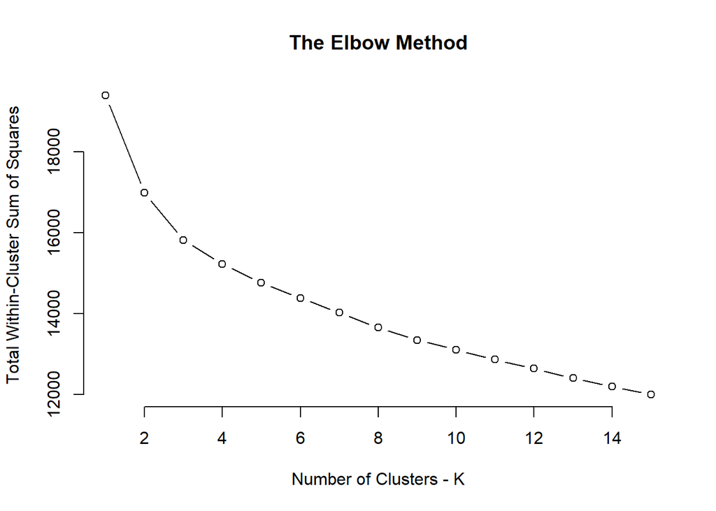

```r
# determining the optimal number of clusters to use for k-means clustering

set.seed(123) # set the seed so that the clustering achieves the same result each time it is run
possible_k_values <- 1:15 # we will be checking k values of 1 through 15

# Elbow Method

# function that returns the total within-cluster sum of squares for the result of k-means clustering with k clusters
get_total_wss <- function(k) {
  kmeans(standardized_imputed_df[, 3:43], k, nstart = 25)$tot.withinss
}
# calculate the total within-cluster sum of squares for k-means clustering with k values of 1 through 15
total_wss_values <- map_dbl(possible_k_values, get_total_wss)
plot(possible_k_values, total_wss_values, type = "b", frame = FALSE, xlab= "Number of Clusters - K",
     ylab = "Total Within-Cluster Sum of Squares", main = "The Elbow Method")
```

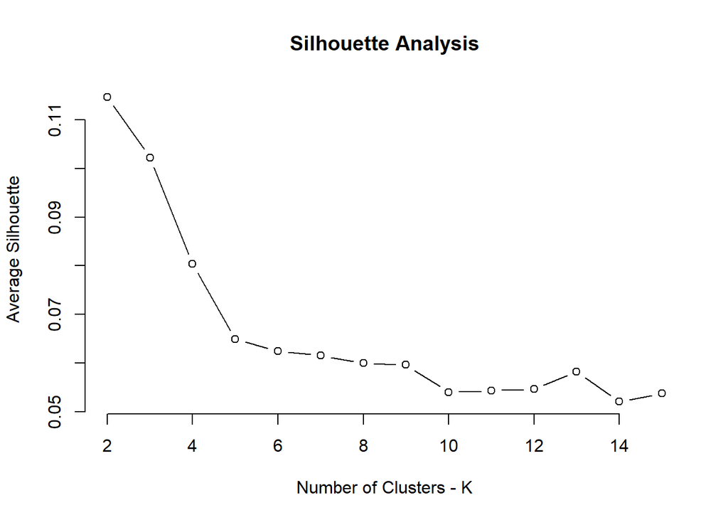

```r
# Silhouette Analysis

possible_k_values <- 2:15 # skip k value of 1 so we don't get an error when calculating average silhouettes

# function that calculates the average silhouette for the result of k-means clustering with k clusters
get_avg_silhouette <- function(k) {
  clstrs <- kmeans(standardized_imputed_df[, 3:43], k, nstart = 25)
  silhouettes <- silhouette(clstrs$cluster, dist(standardized_imputed_df[, 3:43]))
  mean(silhouettes[, "sil_width"])
}

# calculate the average silhouette for k-means clustering with k values of 1 through 15
avg_silhouette_values <- map_dbl(possible_k_values, get_avg_silhouette)
plot(possible_k_values, avg_silhouette_values, type = "b", frame = FALSE, xlab= "Number of Clusters - K",
     ylab = "Average Silhouette", main = "Silhouette Analysis")
```

After choosing 3 as the best possible value of k, k-means clustering is performed on the dataset of starting pitchers.

```r
# based on the Elbow Method and Silhouette Analysis, we will make an educated guess of 3 as our value of k for k-means clustering
set.seed(123) # set seed

# k-means clustering with k = 3
clusters <- kmeans(standardized_imputed_df[, 3:43], 3, nstart = 25)

# add each player's cluster to the original dataframe and the imputed dataframe
df$cluster <- as.factor(clusters$cluster)
imputed_df$cluster <- as.factor(clusters$cluster)
df <- df[c(1, 2, 47, 3:46)]
imputed_df <- imputed_df[c(1, 2, 44, 3:43)]
```

In order to analyze the three clusters, cluster-wide means and medians are calculated for each feature. When examining the clusters, we can give descriptive names to each of the clusters based on their cluster-wide means and medians. Based on these pitchers' high velocities on all of their pitchers and high number of standardized runs saved with the fastball, we will call pitchers in Cluster 1 "power" pitchers. Based on these pitchers' low walk percentages and high first-strike percentages, we will call pitchers in Cluster 2 "control" pitchers. Lastly, based on their lack of identifying characteristics and the lack of features that they excel at, we will call pitchers in Cluster 3 "standard" pitchers.

```r
# create seperate dataframes for each of the three clusters for both the original data and the imputed data
cluster1 <- subset(df, cluster == "1")
cluster2 <- subset(df, cluster == "2")
cluster3 <- subset(df, cluster == "3")
cluster1_imputed <- subset(imputed_df, cluster == "1")
cluster2_imputed <- subset(imputed_df, cluster == "2")
cluster3_imputed <- subset(imputed_df, cluster == "3")

# calculating each cluster's means for each attribute
cluster1_avgs <- colMeans(cluster1_imputed[sapply(cluster1_imputed, is.numeric)])
cluster2_avgs <- colMeans(cluster2_imputed[sapply(cluster2_imputed, is.numeric)])
cluster3_avgs <- colMeans(cluster3_imputed[sapply(cluster3_imputed, is.numeric)])
# calculating each cluster's medians for each attribute
cluster1_meds <- colMedians(cluster1_imputed[sapply(cluster1_imputed, is.numeric)])
cluster2_meds <- colMedians(cluster2_imputed[sapply(cluster2_imputed, is.numeric)])
cluster3_meds <- colMedians(cluster3_imputed[sapply(cluster3_imputed, is.numeric)])

# create a new dataframe of the per-cluster averages
cluster_avgs <- data.frame(cluster1_avgs, cluster2_avgs, cluster3_avgs)
# create a new dataframe of the per-cluster medians
cluster_meds <- data.frame(cluster1_meds, cluster2_meds, cluster3_meds)

cluster_avgs
```

```
##                          cluster1_avgs cluster2_avgs cluster3_avgs
## ip                        683.09891892  537.67280000  424.68292683
## k_percent                   0.22116216    0.17991200    0.15654268
## bb_percent                  0.07882703    0.07040800    0.08270732
## babip                       0.29451351    0.28896800    0.30396341
## gb_percent                  0.43500541    0.39451200    0.47727439
## ld_percent                  0.21203243    0.20294400    0.20615244
## fb_percent                  0.35299459    0.40255200    0.31657317
## iffb_percent                0.09725946    0.10710400    0.07805488
## soft_percent                0.18020000    0.18956000    0.17142683
## med_percent                 0.48901081    0.50538400    0.52091463
## hard_percent                0.33095676    0.30520000    0.30781707
## o_swing_percent             0.30880541    0.30200000    0.28249390
## swing_percent               0.46765946    0.46219200    0.44348171
## contact_percent             0.77600541    0.81369600    0.83118293
## zone_percent                0.43983784    0.45297600    0.44007927
## first_strike_percent        0.60875676    0.61384000    0.58756098
## swinging_strike_percent     0.10464324    0.08583200    0.07460366
## lob_percent                 0.73271892    0.72097600    0.69255488
## z_swing_percent             0.66978378    0.65546400    0.64817683
## o_contact_percent           0.63173514    0.69946400    0.70354268
## z_contact_percent           0.86129730    0.87766400    0.90245732
## pace                       22.85405405   21.28320000   21.57134146
## ev_imp                     88.35726126   88.38778667   89.09113821
## fa_percent                  0.56155676    0.53784800    0.58178049
## sl_percent_imp              0.17052252    0.13557760    0.11784512
## ct_percent_imp              0.07197333    0.09136800    0.10256748
## cb_percent_imp              0.12037550    0.11094880    0.12733211
## ch_percent_imp              0.12334775    0.15570240    0.11500813
## sf_percent_imp              0.08273550    0.08602027    0.08267683
## fa_standardized_runs       -0.11772973   -0.29592000   -0.63701220
## sl_standardized_runs_imp    0.40356036   -0.62431467   -0.60361382
## ct_standardized_runs_imp   -1.76672432   -1.86752533   -1.31353659
## cb_standardized_runs_imp   -0.33063423   -0.41814933   -0.86270325
## ch_standardized_runs_imp   -0.45291171   -0.31516267   -0.88946748
## sf_standardized_runs_imp   -0.50038198   -0.75966933   -1.96337805
## fa_velo                    93.00378378   89.24480000   91.10548780
## sl_velo_imp                84.82306306   81.40768000   83.44150407
## ct_velo_imp                89.14129730   86.10261333   87.99719512
## cb_velo_imp                78.52641441   74.23317333   77.11491870
## ch_velo_imp                85.29390991   80.83936000   83.51947154
## sf_velo_imp                85.66850450   81.53173333   84.14585366
```

```r
cluster_meds
```

```
##                          cluster1_meds cluster2_meds cluster3_meds
## ip                        519.00000000  432.00000000   261.0500000
## k_percent                   0.21700000    0.17900000     0.1570000
## bb_percent                  0.07700000    0.07000000     0.0805000
## babip                       0.29500000    0.29100000     0.3040000
## gb_percent                  0.43700000    0.39000000     0.4770000
## ld_percent                  0.21100000    0.20300000     0.2055000
## fb_percent                  0.35200000    0.40500000     0.3145000
## iffb_percent                0.09700000    0.10500000     0.0785000
## soft_percent                0.17900000    0.18600000     0.1725000
## med_percent                 0.49000000    0.50900000     0.5220000
## hard_percent                0.32400000    0.30500000     0.3050000
## o_swing_percent             0.30800000    0.30200000     0.2810000
## swing_percent               0.46600000    0.46400000     0.4445000
## contact_percent             0.78000000    0.81400000     0.8305000
## zone_percent                0.44200000    0.45300000     0.4400000
## first_strike_percent        0.60600000    0.61200000     0.5900000
## swinging_strike_percent     0.10300000    0.08600000     0.0750000
## lob_percent                 0.73300000    0.72300000     0.6960000
## z_swing_percent             0.67100000    0.65300000     0.6490000
## o_contact_percent           0.63800000    0.70000000     0.7005000
## z_contact_percent           0.86300000    0.88000000     0.9030000
## pace                       22.80000000   21.10000000    21.7000000
## ev_imp                     88.40000000   88.39333333    89.0000000
## fa_percent                  0.56800000    0.54300000     0.5865000
## sl_percent_imp              0.17100000    0.13800000     0.1085000
## ct_percent_imp              0.05413333    0.06146667     0.0783000
## cb_percent_imp              0.10600000    0.10800000     0.1220000
## ch_percent_imp              0.11800000    0.15100000     0.1070000
## sf_percent_imp              0.07233333    0.08240000     0.0720000
## fa_standardized_runs       -0.06000000   -0.33000000    -0.5850000
## sl_standardized_runs_imp    0.50000000   -0.26000000    -0.4763333
## ct_standardized_runs_imp   -0.72000000   -0.81733333    -0.7393333
## cb_standardized_runs_imp   -0.21600000   -0.42000000    -0.5500000
## ch_standardized_runs_imp   -0.24000000   -0.14000000    -0.6950000
## sf_standardized_runs_imp   -0.42133333   -0.46533333    -2.0253333
## fa_velo                    92.90000000   89.60000000    91.1500000
## sl_velo_imp                84.90000000   81.90000000    83.4000000
## ct_velo_imp                89.00000000   86.25333333    88.1000000
## cb_velo_imp                78.60000000   74.70000000    77.4000000
## ch_velo_imp                85.10000000   81.20000000    83.7500000
## sf_velo_imp                85.80000000   81.29333333    84.2033333
```

After k-means clustering has been performed on the starting pitchers dataset containing only the pitching style metrics, pitching success metrics; like ERA, FIP, and WHIP; for the same set of starting pitchers over the same timeframe will be read into a new dataframe, which will also identify each starting pitcher's cluster.

```r
# read the pitcher success data file into a dataframe
sp_success <- read.csv("sp_success_data 2010-2019.csv", header = TRUE, check.names = TRUE)
colnames(sp_success)[1] <- "name"
sp_success <- sp_success %>% rename(team = Team, era = ERA, siera = SIERA, whip = WHIP, fip = FIP, xfip = xFIP,
                                    war = WAR, rar = RAR, wpa = WPA)
sp_success$cluster <- as.factor(clusters$cluster)
sp_success <- sp_success[c(1, 2, 11, 3:10)]
head(sp_success)
```

```
##              name    team cluster  era siera whip  fip xfip  war   rar   wpa
## 1 Clayton Kershaw Dodgers       1 2.31  2.96 0.96 2.64 2.86 59.0 508.8 38.21
## 2  Jose Fernandez Marlins       1 2.58  2.85 1.05 2.44 2.72 14.5 125.2  8.95
## 3    Jacob deGrom    Mets       1 2.62  3.20 1.05 2.78 3.04 31.5 281.1 18.47
## 4     Mike Soroka  Braves       1 2.79  4.26 1.15 3.38 3.82  4.6  44.8  3.25
## 5  Walker Buehler Dodgers       1 2.85  3.40 0.99 2.97 3.28  8.2  77.6  5.26
## 6       Rich Hill   - - -       2 2.92  3.45 1.05 3.43 3.55 10.0  92.6  5.24
```

In order to analyze the three clusters based on pitching success, cluster-wide means and medians are calculated for each feature.

```r
# create seperate dataframes for each of the three clusters for the pitcher success data
cluster1_success <- subset(sp_success, cluster == "1")
cluster2_success <- subset(sp_success, cluster == "2")
cluster3_success <- subset(sp_success, cluster == "3")

# calculating each cluster's means for each attribute
cluster1_success_avgs <- colMeans(cluster1_success[sapply(cluster1_success, is.numeric)])
cluster2_success_avgs <- colMeans(cluster2_success[sapply(cluster2_success, is.numeric)])
cluster3_success_avgs <- colMeans(cluster3_success[sapply(cluster3_success, is.numeric)])

# create a new dataframe of the per-cluster averages
cluster_success_avgs <- data.frame(cluster1_success_avgs, cluster2_success_avgs, cluster3_success_avgs)
```

Two of the best metrics to quantify a pitcher's performance are Skill-Interactive Earned Run Average (SIERA) and Expected Fielding Independent Pitching (xFIP) because they attempt to eliminate factors the pitcher can't control himself, such as the defense in xFIP and the type of ball in play for SIERA. More information on each of these metrics can be found here: xFIP - https://library.fangraphs.com/pitching/xfip/, SIERA - https://library.fangraphs.com/pitching/siera/.

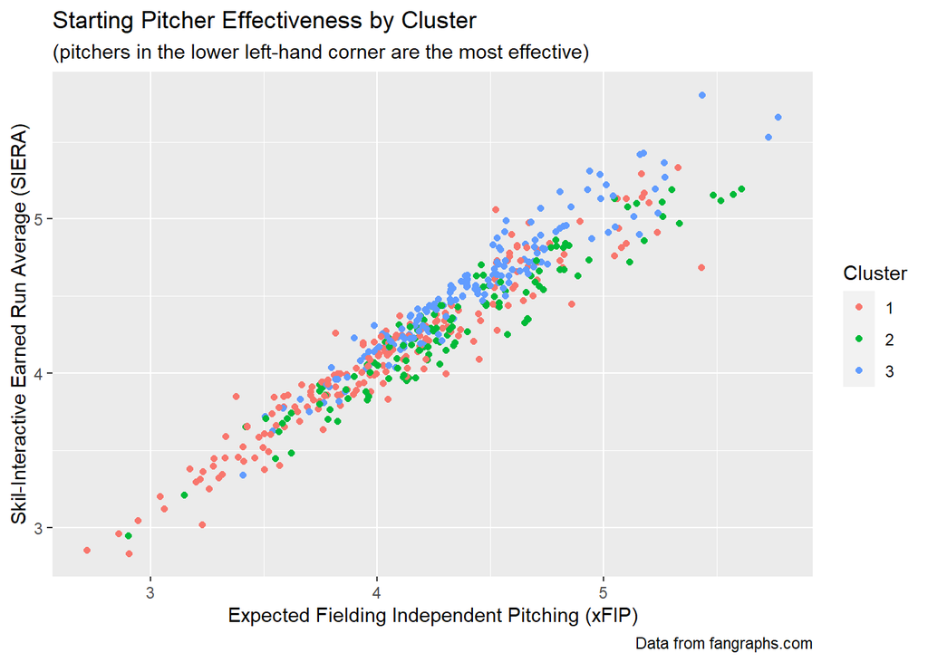

```r
# creating a graphic to measure the success of each of the three clusters
ggplot(data = sp_success) +
  geom_point(mapping = aes(x = xfip, y = siera, color = cluster), position = "jitter") +
  labs(title = "Starting Pitcher Effectiveness by Cluster",
       subtitle = "(pitchers in the lower left-hand corner are the most effective)",
       x = "Expected Fielding Independent Pitching (xFIP)",
       y = "Skil-Interactive Earned Run Average (SIERA)",
       color = "Cluster",
       caption = "Data from fangraphs.com")
```

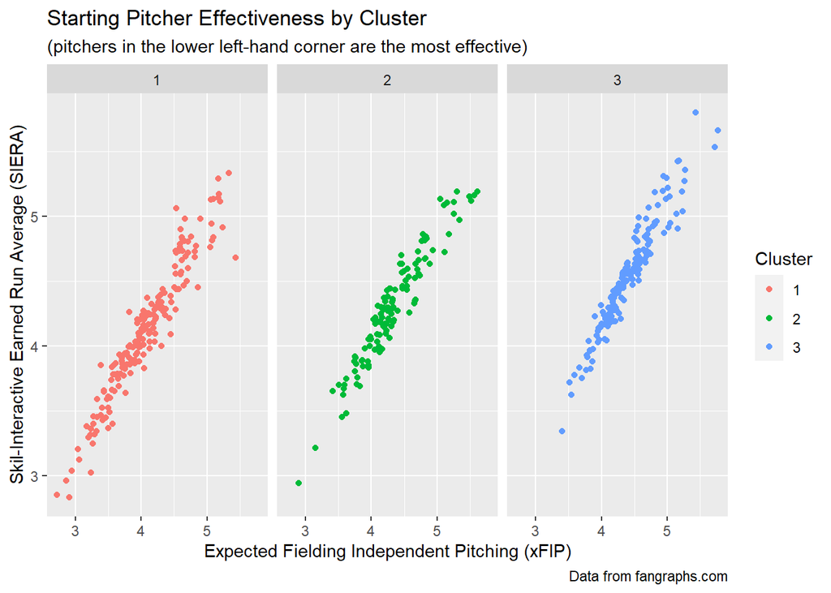

```r
ggplot(data = sp_success) +
  geom_point(mapping = aes(x = xfip, y = siera, color = cluster), position = "jitter") +
  facet_wrap(~ cluster, nrow = 1) +
  labs(title = "Starting Pitcher Effectiveness by Cluster",
       subtitle = "(pitchers in the lower left-hand corner are the most effective)",
       x = "Expected Fielding Independent Pitching (xFIP)",
       y = "Skil-Interactive Earned Run Average (SIERA)",
       color = "Cluster",
       caption = "Data from fangraphs.com")
```

Based on these graphics attempting to quantify a pitcher's success through SIERA and xFIP, it can be seen that as a general rule, pitchers in Cluster 1 ("power" pitchers) are the most successful, followed by Cluster 2 ("control" pitchers), and then Cluster 3 ("standard" pitchers).